# Lab Name

## More Practice

1. Mutate the data frame so that it includes a new variable that contains the average speed, `avg_speed` traveled by the plane for each flight (in mph). **Hint:** Average speed can be calculated as distance divided by number of hours of travel, and note that `air_time` is given in minutes.

```r
nycflights <- nycflights %>%
    mutate(at_in_hours = air_time / 60)

nycflights <- nycflights %>%
    mutate(avg_speed = distance / at_in_hours)
```

2. Make a scatterplot of `avg_speed` vs. `distance`. Describe the relationship between average speed and distance. **Hint:** Use `geom_point()`.

*Average speed rises steeply as distance increases up to a limit of approximately* *425 mph at 1000 miles traveled, then rises very gradually toward 500 mph as distance traveled approaches 5000. To examine the* *relationship more clearly at distances < 1000, we’ll show the graph again using a logarithmic scale on the x-axis.*

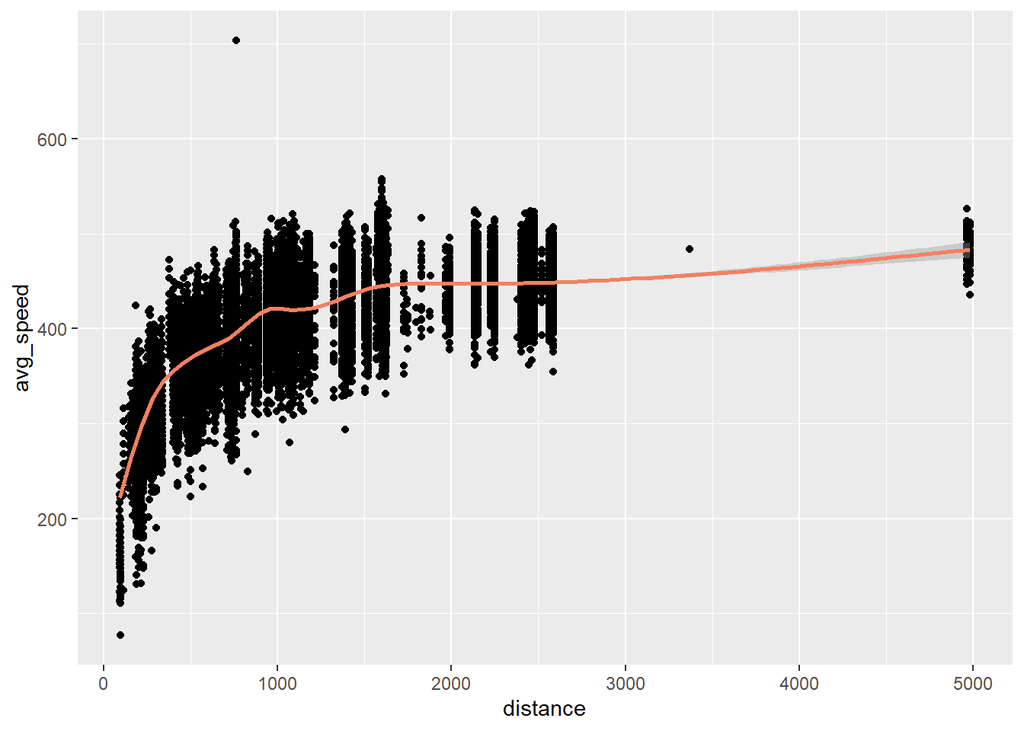

```r
ggplot(nycflights, aes(distance, avg_speed)) +
  geom_point() +
  geom_smooth(color="#f68060")
```

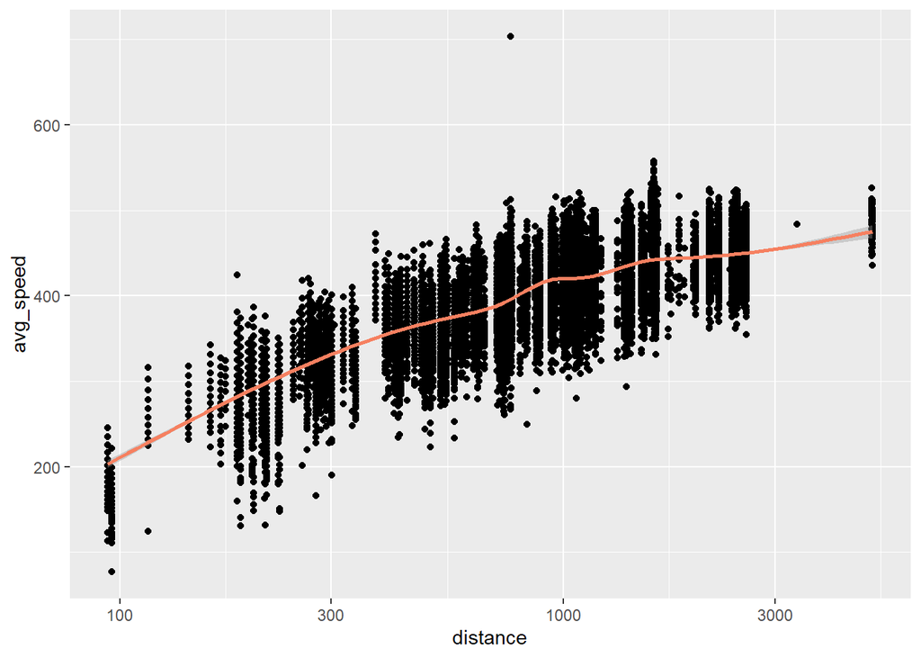

```r
ggplot(nycflights, aes(distance, avg_speed)) +
  geom_point() +
  geom_smooth(color="#f68060")+
  scale_x_log10()
```

3. Replicate the following plot. **Hint:** The data frame plotted only contains flights from American Airlines, Delta Airlines, and United Airlines, and the points are colored by `carrier`. Once you replicate the plot, determine (roughly) what the cutoff point is for departure delays where you can still expect to get to your destination on time.

*By subsetting the data to examine only cases where arrival and departure time* *are both less than 50 minutes, and changing the plot to show the regression line for each carrier, we can see there is on average* *a linear relationship between minutes delayed on departure, and minutes delayed on arrival. It appears from the graph that we can* *depart up to approximately 15 minutes late, and still arrive on average less than 5 minutes late.*

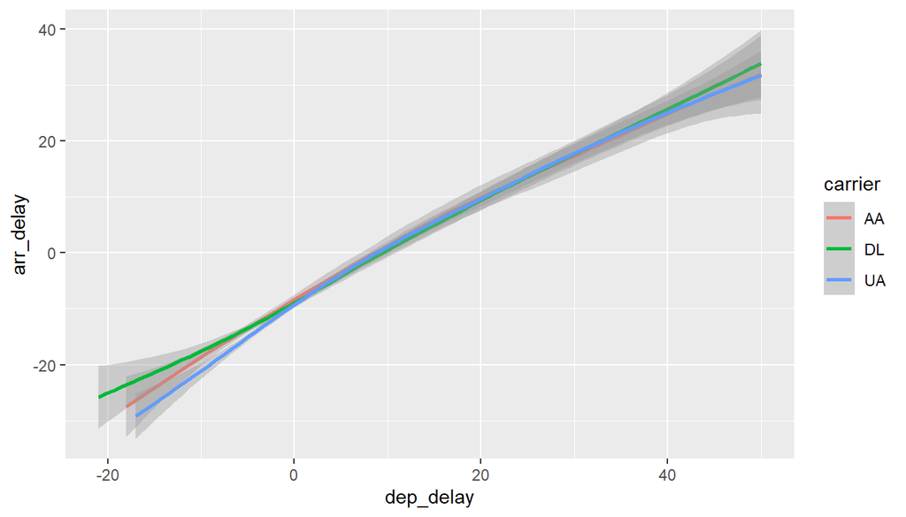